##### Meng Zhang,<sup>1,2</sup> Peter Wagner,<sup>1</sup> Benjamin Coueraud,<sup>1</sup> Imanol Irizar Da Silva,<sup>1</sup> Marek Junghans<sup>1</sup>

<sup>1</sup> German Aerospace Center, Institute of Transportation Systems  
<sup>2</sup> meng.zhang@dlr.de

# Introduction

The study, using real-world data, aims to model the interaction between **crossing bicycles** and **right-turning vehicles**, attempting to alter the simulator’s guidance at the tactical level (Michon 1985). In ten days of video recordings from an urban intersection (Figure 1), 517 valid cases were collected.

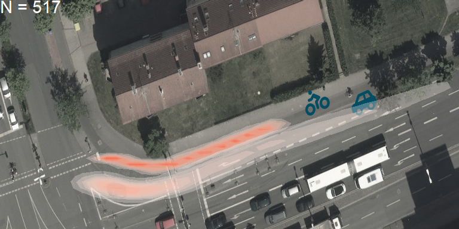

Figure 1: Trajectory distribution of crossing bicycles and right-turning vehicles, collected from the application platform (Knake-Langhorst et al. 2016) at the intersection in Braunschweig, Germany

# Modeling the Interaction

A logistic regression model of crossing order was employed with features of bicycles (0) and vehicles (1): speed (v), speed difference (dv), the distance between the current position and the crossing point (d2x), predicted PET (ppet). The data set was split into training data set (80%) and testing data set (20%). Models with different feature combinations were cross-validated (Table 1).

$$\log\left(\frac{p}{1-p}\right) = \beta_0 + \beta_1 x_1 + \beta_2 x_2 + \ldots + \beta_k x_k$$

[interactive chart not shown]

Figure 2: Sigmoid curve of crosssing order (0: Bicycle first, 1: Vehicle first) and ppet (-: Vehicle would be first, +: Bicycle would be first)

Table 1: Results of models (bold the selected model).

| k | combination | accuracy |
| --- | --- | --- |
| 1 | ppet | 84.6% |
| 2 | d2x_0, d2x_1 | 89% |
| 2 | v_0, v_1 | 84.8% |
| 4 | d2x_0, d2x_1, v_0, v_1 | 93.4% |
| 4 | d2x_0, v_0, v_1, dv | 85.3% |
| 5 | ppet, d2x_1, v_0, v_1, dv | 91.5% |
| 6 | ppet, d2x_0, d2x_1, v_0, v_1, dv | 93.4% |

# Simulation

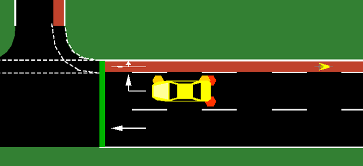

Figure 3: A simplified intersection in SUMO (Lopez et al. 2018), including straight, richt-turning lane, and bicycle lanes

The selected model was implemented in SUMO: at a distance of 20m before the crossing point the crossing order was estimated, and the lagging object was forced to slow down. A comparison between reality, SUMO’s default model, and this new model was performed.

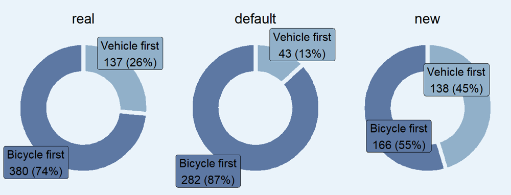

Figure 4: Crossing order of real data and simulated data based on default and new sumo models

- In reality, 74% bicycles crossed the intersection before vehicles.
- In the default model, vehicles were more conservative, with the proportion of bicycles first approaching 90%.
- The new model brings this ratio closer to 50%, but it still differs from the ratio in real-world data.

[interactive chart not shown]

Figure 5: Post-Enchroachment Time (vehicle first: light blue; bicycle first: dark blue)

- In the default model, PET distributions vary significantly based on the crossing order. In the real-world data and the new model, PET distributions are similar, however, there is still a ~1s gap.

# Conclusion

The study of interactions between bicycles and vehicles in reality contributes to improving the realism of simulators. This attempt did not improve the distribution of the crossing order in the simulation, but the distribution of PET is closer to reality.

Knake-Langhorst, Sascha, Kay Gimm, Tobias Frankiewicz, and Frank Köster. 2016. “Test Site AIM–Toolbox and Enabler for Applied Research and Development in Traffic and Mobility.” *Transportation Research Procedia* 14: 2197–2206.

Lopez, Pablo Alvarez, Michael Behrisch, Laura Bieker-Walz, Jakob Erdmann, Yun-Pang Flötteröd, Robert Hilbrich, Leonhard Lücken, Johannes Rummel, Peter Wagner, and Evamarie Wießner. 2018. “Microscopic Traffic Simulation Using Sumo.” In *2018 21st International Conference on Intelligent Transportation Systems (ITSC)*, 2575–82. IEEE.

Michon, John A. 1985. “A Critical View of Driver Behavior Models: What Do We Know, What Should We Do?” In *Human Behavior and Traffic Safety*, 485–524. Springer.

Investigating interactions between bicycles and vehicles at intersections using real-world trajectories

[figure not shown]

[figure not shown]